# Лабораторная работа №1

Операционные системы

Закиров Н.Д., НКАбд-03-23

Российский университет дружбы народов, Москва, Россия

26 февраля 2024

# Информация

## Докладчик

- Закиров Нурислам Дамирович
- Студент 1 курса
- Группа: НКАбд-03-23
- Российский университет дружбы народов

# Лабораторная работа

## Цель работы

Целью данной работы является приобретение практических навыков установки операционной системы на виртуальную машину, настройки минимально необходимых для дальнейшей работы сервисов.

## Создание виртуальной машины

- Качаем установщик VirtualBox c официального сайта
- Устанавливаем данную программу на персональный компьютер
- У меня виртуальная машина уже была установленна, поэтому данный этап уже выполнен(рис. 1).

[figure not shown]

Ярлык VirtualBox

## Работа с операционной системой после установки

Устанавливаем операционную систему, в нашем случае это fedora. Для этого качаем с браузера ОС в образе диска, после чего производим установку fedora на нашу виртуальную машину. Данный этап у меня тоже был выполнен до лаболаторной работы. (рис. 2).

[figure not shown]

Fedora на виртуальной машине VirtualBox

## Работа с операционной системой после установки

- Запускаем терминал при помощи комбинацию клавиш Win+Enter
- Переключаемся на роль супер-пользователя(рис. 3).

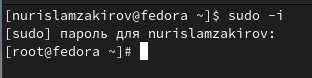

Переклчение на роль супер-пользователя

## Работа с операционной системой после установки

Устанавливаем средство pandoc для работы с языком разметки Markdown и дистрибутив TexLive, но так как до начала лаболаторной работы всё было установленно, данный этап был пропущен. Поэтому только обновляем все пакеты при помощи dnf -y update (рис. 4).

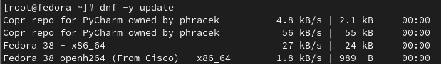

Обновление всех пакетов

## Работа с операционной системой после установки

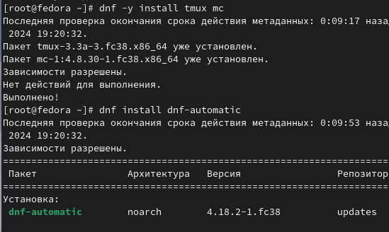

Установка програмы

## Работа с операционной системой после установки

Запускаем таймер при помощи команды systemctl enable –now dnf-automatic.timer(рис. 6).

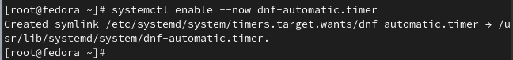

Запуск таймера

## Работа с операционной системой после установки

Открываем файл congig при помощи текстового редактора mousepad (рис. 7).

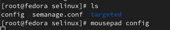

Открытие файла

## Работа с операционной системой после установки

В открывшимся файле изменяем заначение SELINUX=enforcing на значение SELINUX=permissive (рис. 8).

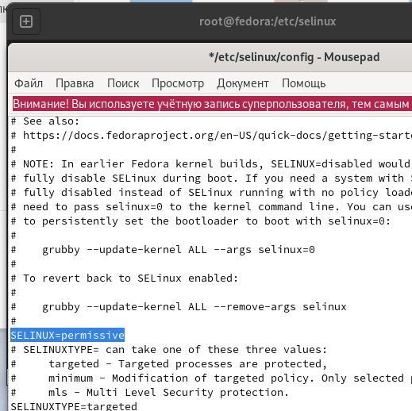

Замена значения в файле

## Работа с операционной системой после установки

- Запускаем терминальный мультиплексор tmux
- Переключаемся на роль супер-пользователя
- Установливаем средства разработки и пакет DKMS
- Перезапускаем виртуальну машину при помощи reboot(рис. 9).

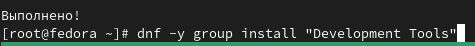

Установка средства разработки

## Установка имени пользователя и названия хоста

- Запускаем терминальный мультиплексор tmux
- Создаем пользователя, задавая свой логин
- Задаем свой пароль(рис. 10).

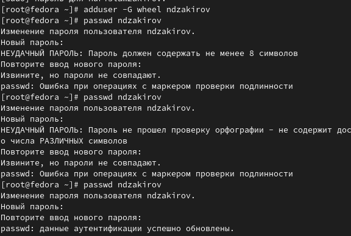

Установка имени пользователя

## Установка имени пользователя и названия хоста

Устанавливем имя хоста и проводим проверку при помощи hostnamectl(рис. 11).

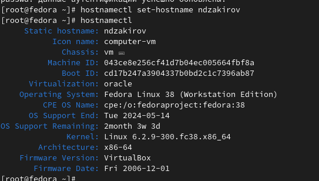

Установка названия хоста

## Установка имени пользователя и названия хоста

Внутри виртуальной машины добавляем своего пользователя в группу vboxsf(рис. 12).

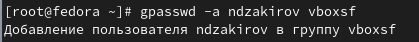

Добавление пользователя в группу vboxsf

# Выполнение дополнительного задания

Получаем инфорамции о версии ядра Linux, частоте процессора, а также модели процессора(рис. 13).

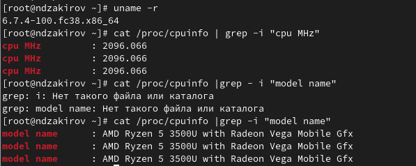

Получение информации

# Выполнение дополнительного задания

Получаем инфорамции о объёме доступной оперативной памяти, типе обнаруженного гипервизора, типе файловой системы корневого раздела, а также о последовательности монтирования файловых систем(рис. 14).

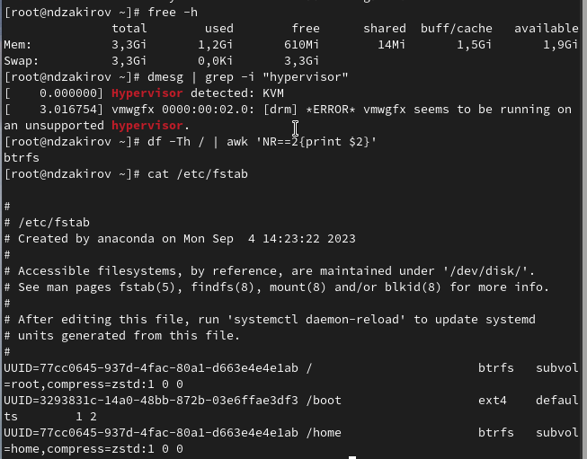

Получение информации

## Вывод

При выполнении данной лабораторной работы я приобрел практические навыки установки операционной системы на виртуальную машину и настройки минимально необходимых для дальнейшей работы сервисов.

## Список литературы

1. Dash P. Getting started with oracle vm virtualbox. Packt Publishing Ltd, 2013. 86 p.
2. Colvin H. Virtualbox: An ultimate guide book on virtualization with virtualbox. CreateSpace Independent Publishing Platform, 2015. 70 p.
3. van Vugt S. Red hat rhcsa/rhce 7 cert guide : Red hat enterprise linux 7 (ex200 and ex300). Pearson IT Certification, 2016. 1008 p.
4. Робачевский А., Немнюгин С., Стесик О. Операционная система unix. 2-е изд. Санкт-Петербург: БХВ-Петербург, 2010. 656 p.
5. Немет Э. et al. Unix и Linux: руководство системного администратора. 4-е изд. Вильямс, 2014. 1312 p.
6. Колисниченко Д.Н. Самоучитель системного администратора Linux. СПб.: БХВ-Петербург, 2011. 544 p.
7. Robbins A. Bash pocket reference. O’Reilly Media, 2016. 156 p.